# Dimensionality Reduction - R Methods

C. Heiser, 2019

**The purpose of this notebook is to perform dimensionality reduction techniques implemented in the R statistical computing language.**

To benchmark these methods, we are using two single-cell RNA-seq datasets: * From [Macosko, *et al.* (2015)](https://www.ncbi.nlm.nih.gov/pubmed/26000488), mouse retina scRNA-seq data generated using DropSeq: GSM1626793 * From [Herring, *et al.* (2018)](https://www.ncbi.nlm.nih.gov/pubmed/29153838), mouse colon scRNA-seq data generated using inDrops: GSM2743164

The first set should be **discrete**, containing highly separable cell distributions from the mouse retina, where the latter will be **continuous**, representing hierarchical, branching cell states in the gut epithelium.

Both datasets have been **preprocessed and feature-selected** to allow for direct input to downstream dimensionality reduction algorithms (rather than first performing PCA to limit dimensional input). These methods are shown in `dev/preprocess_and_filter.ipynb`.

```r
setwd('../../scrna2019/') # insert relative path to GLM-PCA directory
```

```
The working directory was changed to /Users/cody/git/scrna2019 inside a notebook chunk. The working directory will be reset when the chunk is finished running. Use the knitr root.dir option in the setup chunk to change the working directory for notebook chunks.
```

```r
source('algs/glmpca.R')
setwd('../furry-couscous/')
source('fcc_utils.r')
library(zinbwave, quietly = T)
library(scRNAseq, quietly = T)
library(SIMLR, quietly = T)
```

Read in feature-selected datasets for testing; both are in cell-by-genes format with cell and gene labels

```r
# read in feature-selected datasets for testing; both are in cells x genes format with cell and gene labels
# continuous data - GEO accession # GSM2743164
colon <- read.csv('../inputs/GSM2743164_rep1_colon_rnaseq.processed.tsv', sep='\t', header = T, row.names = 1)
# discrete data - GEO accession # GSM1626793
retina <- read.csv('../inputs/GSM1626793_P14Retina_1.processed.tsv', sep='\t', header = T, row.names = 1)
```

### ZINB-WaVE

From [Risso, *et al.* (2018)](https://www.nature.com/articles/s41467-017-02554-5), ZINB-WaVE is a zero-inflated negative binomial model for low-dimensional representations of scRNA-seq counts data. Available on [Bioconductor](https://bioconductor.org/packages/release/bioc/html/zinbwave.html).

Create SummarizedExperiment object from counts data, then perform ZINB-WaVE.

```r
# transpose matrix to genes x cells format
colon_expt <- SummarizedExperiment(assays = list(counts=data.matrix(t(colon))))
# perform ZINB-WAVE analysis
colon_zinbwave <- zinbwave(colon_expt, K=2, epsilon=1000, verbose=T)
```

[output not shown]

```
   user  system elapsed
  0.109   0.108   9.270
```

```
After right optimization = -1954413.16693993
After orthogonalization = -1953359.22714644
'package:stats' may not be available when loading'package:stats' may not be available when loading
```

```
   user  system elapsed
  0.114   0.127   9.794
```

```
After left optimization = -1857553.14964822
After orthogonalization = -1857528.4824507
Iteration 2
penalized log-likelihood = -1857528.4824507
After dispersion optimization = -1857528.4824507
'package:stats' may not be available when loading'package:stats' may not be available when loading
```

```
   user  system elapsed
  0.095   0.086   8.119
```

```
After right optimization = -1840719.89460439
After orthogonalization = -1840717.3781493
'package:stats' may not be available when loading'package:stats' may not be available when loading
```

```
   user  system elapsed
  0.092   0.088   9.138
```

```
After left optimization = -1832938.58016803
After orthogonalization = -1832933.98079704
Iteration 3
penalized log-likelihood = -1832933.98079704
After dispersion optimization = -1832933.98079704
'package:stats' may not be available when loading'package:stats' may not be available when loading
```

```
   user  system elapsed
  0.085   0.079   7.294
```

```
After right optimization = -1828558.57081663
After orthogonalization = -1828554.93668888
'package:stats' may not be available when loading'package:stats' may not be available when loading
```

```
   user  system elapsed
  0.092   0.087   8.048
```

```
After left optimization = -1825412.83757447
After orthogonalization = -1825409.98419214
Iteration 4
penalized log-likelihood = -1825409.98419214
After dispersion optimization = -1825409.98419214
'package:stats' may not be available when loading'package:stats' may not be available when loading
```

```
   user  system elapsed
  0.091   0.084   8.130
```

```
After right optimization = -1823664.08375842
After orthogonalization = -1823662.96089303
'package:stats' may not be available when loading'package:stats' may not be available when loading
```

```
   user  system elapsed
  0.085   0.079   6.330
```

```
After left optimization = -1822549.53554264
After orthogonalization = -1822548.64687976
Iteration 5
penalized log-likelihood = -1822548.64687976
After dispersion optimization = -1822548.64687976
'package:stats' may not be available when loading'package:stats' may not be available when loading
```

```
   user  system elapsed
  0.085   0.074   6.028
```

```
After right optimization = -1822021.75547455
After orthogonalization = -1822021.51855564
'package:stats' may not be available when loading'package:stats' may not be available when loading
```

```
   user  system elapsed
  0.085   0.078   6.382
```

```
After left optimization = -1821735.83057556
After orthogonalization = -1821735.64445513
Iteration 6
penalized log-likelihood = -1821735.64445513
After dispersion optimization = -1821735.64445513
'package:stats' may not be available when loading'package:stats' may not be available when loading
```

```
   user  system elapsed
  0.083   0.074   6.156
```

```
After right optimization = -1821587.77395167
After orthogonalization = -1821587.66929906
'package:stats' may not be available when loading'package:stats' may not be available when loading
```

```
   user  system elapsed
  0.092   0.088   6.618
```

```
After left optimization = -1821500.50748264
After orthogonalization = -1821500.47443572
Iteration 7
penalized log-likelihood = -1821500.47443572
After dispersion optimization = -1821500.47443572
'package:stats' may not be available when loading'package:stats' may not be available when loading
```

```
   user  system elapsed
  0.091   0.079   6.209
```

```
After right optimization = -1821446.04227171
After orthogonalization = -1821445.98690693
'package:stats' may not be available when loading'package:stats' may not be available when loading
```

```
   user  system elapsed
  0.099   0.092   7.880
```

```
After left optimization = -1821403.1331849
After orthogonalization = -1821403.12717982
Iteration 8
penalized log-likelihood = -1821403.12717982
ok
```

Plot resulting 2D embedding:

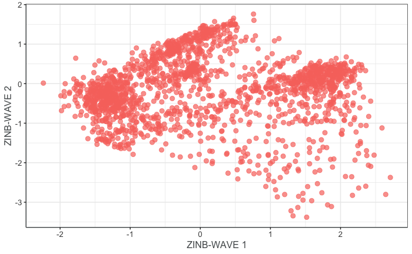

```r
plot.DR(data.frame(colon_zinbwave@reducedDims$zinbwave), name = 'ZINB-WAVE')
```

Perform same steps on retina data

```r
# create SummarizedExperiment object from counts data
# transpose matrix to genes x cells format
retina_expt <- SummarizedExperiment(assays = list(counts=data.matrix(t(retina))))
# perform ZINB-WAVE analysis
retina_zinbwave <- zinbwave(retina_expt, K=2, epsilon=1000, verbose=T, maxiter.optimize=150)
```

[output not shown]

```
   user  system elapsed
  0.106   0.092   6.289
```

```
After right optimization = -775003.028385613
After orthogonalization = -773617.237743976
'package:stats' may not be available when loading'package:stats' may not be available when loading
```

```
   user  system elapsed
  0.112   0.105   6.129
```

```
After left optimization = -749814.462002044
After orthogonalization = -749771.035060223
Iteration 2
penalized log-likelihood = -749771.035060223
After dispersion optimization = -749771.035060223
'package:stats' may not be available when loading'package:stats' may not be available when loading
```

```
   user  system elapsed
  0.103   0.092   7.521
```

```
After right optimization = -745332.391395854
After orthogonalization = -745311.288899434
'package:stats' may not be available when loading'package:stats' may not be available when loading
```

```
   user  system elapsed
  0.088   0.075   5.678
```

```
After left optimization = -744117.762663226
After orthogonalization = -744116.457116206
Iteration 3
penalized log-likelihood = -744116.457116206
After dispersion optimization = -744116.457116206
'package:stats' may not be available when loading'package:stats' may not be available when loading
```

```
   user  system elapsed
  0.097   0.089   7.252
```

```
After right optimization = -743549.674990021
After orthogonalization = -743546.300987402
'package:stats' may not be available when loading'package:stats' may not be available when loading
```

```
   user  system elapsed
  0.091   0.078   5.865
```

```
After left optimization = -743256.37189917
After orthogonalization = -743256.152627038
Iteration 4
penalized log-likelihood = -743256.152627038
After dispersion optimization = -743256.152627038
'package:stats' may not be available when loading'package:stats' may not be available when loading
```

```
   user  system elapsed
  0.088   0.076   7.203
```

```
After right optimization = -743070.937814671
After orthogonalization = -743069.836641573
'package:stats' may not be available when loading'package:stats' may not be available when loading
```

```
   user  system elapsed
  0.086   0.073   5.407
```

```
After left optimization = -742950.153602084
After orthogonalization = -742950.089102395
Iteration 5
penalized log-likelihood = -742950.089102395
After dispersion optimization = -742950.089102395
'package:stats' may not be available when loading'package:stats' may not be available when loading
```

```
   user  system elapsed
  0.084   0.072   6.230
```

```
After right optimization = -742841.027093486
After orthogonalization = -742840.530672368
'package:stats' may not be available when loading'package:stats' may not be available when loading
```

```
   user  system elapsed
  0.086   0.078   6.225
```

```
After left optimization = -742765.759479467
After orthogonalization = -742765.739543495
Iteration 6
penalized log-likelihood = -742765.739543495
After dispersion optimization = -742765.739543495
'package:stats' may not be available when loading'package:stats' may not be available when loading
```

```
   user  system elapsed
  0.086   0.075   7.023
```

```
After right optimization = -742702.580404446
After orthogonalization = -742702.376374795
'package:stats' may not be available when loading'package:stats' may not be available when loading
```

```
   user  system elapsed
  0.085   0.072   5.762
```

```
After left optimization = -742655.045158091
After orthogonalization = -742655.037975027
Iteration 7
penalized log-likelihood = -742655.037975027
After dispersion optimization = -742655.037975027
'package:stats' may not be available when loading'package:stats' may not be available when loading
```

```
   user  system elapsed
  0.084   0.071   5.622
```

```
After right optimization = -742587.552087321
After orthogonalization = -742587.151965696
'package:stats' may not be available when loading'package:stats' may not be available when loading
```

```
   user  system elapsed
  0.084   0.075   5.365
```

```
After left optimization = -742519.219635187
After orthogonalization = -742519.217929236
Iteration 8
penalized log-likelihood = -742519.217929236
After dispersion optimization = -742519.217929236
'package:stats' may not be available when loading'package:stats' may not be available when loading
```

```
   user  system elapsed
  0.087   0.069   5.363
```

```
After right optimization = -742466.301233883
After orthogonalization = -742466.105034503
'package:stats' may not be available when loading'package:stats' may not be available when loading
```

```
   user  system elapsed
  0.086   0.078   5.738
```

```
After left optimization = -742423.191917657
After orthogonalization = -742423.191107555
Iteration 9
penalized log-likelihood = -742423.191107555
After dispersion optimization = -742423.191107555
'package:stats' may not be available when loading'package:stats' may not be available when loading
```

```
   user  system elapsed
  0.081   0.070   5.518
```

```
After right optimization = -742389.579667125
After orthogonalization = -742389.528599709
'package:stats' may not be available when loading'package:stats' may not be available when loading
```

```
   user  system elapsed
  0.089   0.075   5.665
```

```
After left optimization = -742364.714027549
After orthogonalization = -742364.713705571
Iteration 10
penalized log-likelihood = -742364.713705571
ok
```

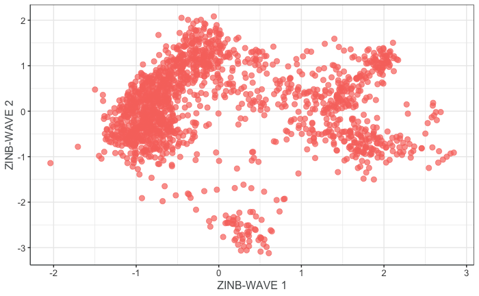

```r
# plot results
plot.DR(data.frame(retina_zinbwave@reducedDims$zinbwave), name = 'ZINB-WAVE')
```

Output ZINB-WaVE results to .csv files

```r
write.csv(data.frame(colon_zinbwave@reducedDims$zinbwave), file = '/Rmethods_out/colon_ZINB-WAVE.csv', row.names = F) # colon data

write.csv(data.frame(retina_zinbwave@reducedDims$zinbwave), file = 'dev/Rmethods_out/retina_ZINB-WAVE.csv', row.names = F) # retina data
```

### GLM-PCA

From [Townes, *et al.* (2019)](https://www.biorxiv.org/content/10.1101/574574v1), GLM-PCA is a generalized linear model-based PCA for dimensionality reduction of scRNA-seq counts data. Available on [GitHub](https://github.com/willtownes/scrna2019).

Let’s start with colon dataset again

```r
# perform GLM-PCA analysis
colon_glmpca <- glmpca(Y=t(colon), L=2, verbose=T)
```

```
[1] "Iteration: 1 | deviance=4.427e+06"
[1] "Iteration: 2 | deviance=3.966e+06"
[1] "Iteration: 3 | deviance=5.512e+42"
[1] "Iteration: 4 | deviance=3.714e+40"
[1] "Iteration: 5 | deviance=2.502e+38"
[1] "Iteration: 6 | deviance=1.686e+36"
[1] "Iteration: 7 | deviance=1.136e+34"
[1] "Iteration: 8 | deviance=7.656e+31"
[1] "Iteration: 9 | deviance=5.158e+29"
[1] "Iteration: 10 | deviance=3.476e+27"
[1] "Iteration: 11 | deviance=2.342e+25"
[1] "Iteration: 12 | deviance=1.578e+23"
[1] "Iteration: 13 | deviance=1.063e+21"
[1] "Iteration: 14 | deviance=7.165e+18"
[1] "Iteration: 15 | deviance=4.828e+16"
```

[output cut: 79 more lines]

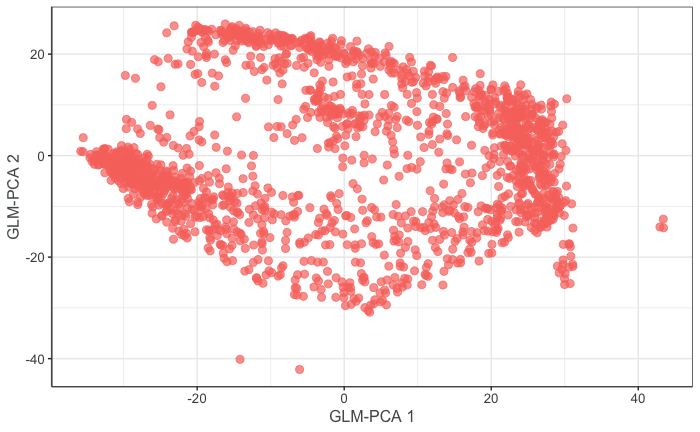

```r
# plot results
plot.DR(colon_glmpca$factors, name='GLM-PCA')
```

Do the same for retina data

```r
# perform GLM-PCA analysis
retina_glmpca <- glmpca(Y=t(retina), L=2, verbose=T)
```

```
[1] "Iteration: 1 | deviance=1.299e+06"
[1] "Iteration: 2 | deviance=1.299e+06"
[1] "Iteration: 3 | deviance=1.972e+10"
[1] "Iteration: 4 | deviance=1.341e+08"
[1] "Iteration: 5 | deviance=1.846e+06"
[1] "Iteration: 6 | deviance=9.378e+05"
[1] "Iteration: 7 | deviance=9.188e+05"
[1] "Iteration: 8 | deviance=9.101e+05"
[1] "Iteration: 9 | deviance=9.041e+05"
[1] "Iteration: 10 | deviance=8.998e+05"
[1] "Iteration: 11 | deviance=8.967e+05"
[1] "Iteration: 12 | deviance=8.945e+05"
[1] "Iteration: 13 | deviance=8.929e+05"
[1] "Iteration: 14 | deviance=8.918e+05"
[1] "Iteration: 15 | deviance=8.91e+05"
[1] "Iteration: 16 | deviance=8.903e+05"
[1] "Iteration: 17 | deviance=8.898e+05"
[1] "Iteration: 18 | deviance=8.894e+05"
[1] "Iteration: 19 | deviance=8.89e+05"
[1] "Iteration: 20 | deviance=8.887e+05"
[1] "Iteration: 21 | deviance=8.885e+05"
[1] "Iteration: 22 | deviance=8.883e+05"
[1] "Iteration: 23 | deviance=8.881e+05"
[1] "Iteration: 24 | deviance=8.879e+05"
[1] "Iteration: 25 | deviance=8.878e+05"
[1] "Iteration: 26 | deviance=8.876e+05"
[1] "Iteration: 27 | deviance=8.875e+05"
[1] "Iteration: 28 | deviance=8.874e+05"
[1] "Iteration: 29 | deviance=8.873e+05"
```

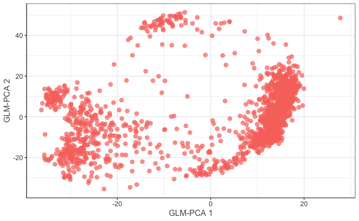

```r
# plot results
plot.DR(retina_glmpca$factors, name='GLM-PCA')
```

Output GLM-PCA results to .csv files

```r
write.csv(colon_glmpca$factors, file = 'Rmethods_out/colon_GLM-PCA.csv', row.names = F) # colon data

write.csv(retina_glmpca$factors, file = 'Rmethods_out/retina_GLM-PCA.csv', row.names = F) # retina data
```

### SIMLR

From [Wang, *et al.* (2017)](https://www.ncbi.nlm.nih.gov/pubmed/28263960), SIMLR is a multikernel learning approach to dimensionality reduction, clustering, and visualization of scRNA-seq counts data. Available on [Bioconductor](https://bioconductor.org/packages/release/bioc/html/SIMLR.html).

First on the colon data. SIMLR requires an expected number of clusters in the dataset. We can use SIMLR to estimate this.

```r
# use SIMLR to estimate number of clusters in dataset for feeding into DR algorithm
# input is raw counts
colon_clu_est <- SIMLR_Estimate_Number_of_Clusters(t(colon), NUMC = 2:14)
print(which.min(colon_clu_est$K1))
```

```
[1] 5
```

Now we can normalize our counts data and feed it into the SIMLR algorithm with the expected number of clusters from above.

```r
colon_norm <- arcsinh.norm(colon, margin=1) # normalize by arcsinh-tranforming fractional counts per gene
# perform SIMLR analysis with the estimated number of clusters from above
colon_SIMLR <- SIMLR(t(colon_norm), c = which.min(colon_clu_est$K1))
```

```
Computing the multiple Kernels.
```

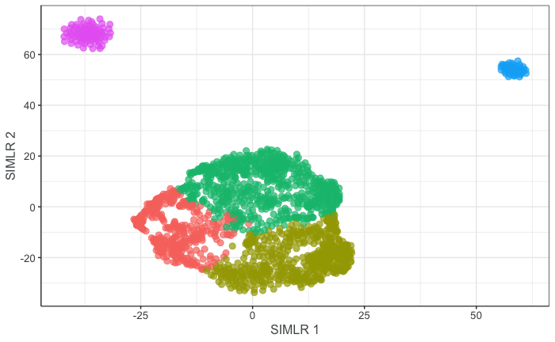

```r
# plot results
plot.DR(data.frame(colon_SIMLR$ydata), colorby = colon_SIMLR$y$cluster, name='SIMLR')
```

Perform same workflow on retina data

```r
# use SIMLR to estimate number of clusters in dataset for feeding into DR algorithm
# input is raw counts
retina_clu_est <- SIMLR_Estimate_Number_of_Clusters(t(retina), NUMC = 2:14)
print(which.min(retina_clu_est$K1))
```

```
[1] 6
```

```r
retina_norm <- arcsinh.norm(retina, margin=1) # normalize by arcsinh-tranforming fractional counts per gene
# perform SIMLR analysis with the estimated number of clusters from above
retina_SIMLR <- SIMLR(t(retina_norm), c = which.min(retina_clu_est$K1))
```

```
Computing the multiple Kernels.
Performing network diffiusion.
Iteration:  1
Iteration:  2
Iteration:  3
Iteration:  4
Iteration:  5
Iteration:  6
Iteration:  7
Iteration:  8
Iteration:  9
Iteration:  10
Iteration:  11
Iteration:  12
Iteration:  13
Iteration:  14
Iteration:  15
Iteration:  16
Iteration:  17
Performing t-SNE.
Epoch: Iteration # 100  error is:  0.316025
Epoch: Iteration # 200  error is:  0.2833499
Epoch: Iteration # 300  error is:  0.2749963
Epoch: Iteration # 400  error is:  0.271489
Epoch: Iteration # 500  error is:  0.269484
Epoch: Iteration # 600  error is:  0.2683096
Epoch: Iteration # 700  error is:  0.2674818
Epoch: Iteration # 800  error is:  0.2668624
Epoch: Iteration # 900  error is:  0.2663731
Epoch: Iteration # 1000  error is:  0.266079
Performing Kmeans.
Performing t-SNE.
Epoch: Iteration # 100  error is:  11.36102
Epoch: Iteration # 200  error is:  0.537637
Epoch: Iteration # 300  error is:  0.5206916
Epoch: Iteration # 400  error is:  0.5179542
Epoch: Iteration # 500  error is:  0.5170503
Epoch: Iteration # 600  error is:  0.5166472
Epoch: Iteration # 700  error is:  0.5164115
Epoch: Iteration # 800  error is:  0.5162554
Epoch: Iteration # 900  error is:  0.5161434
Epoch: Iteration # 1000  error is:  0.5160605
```

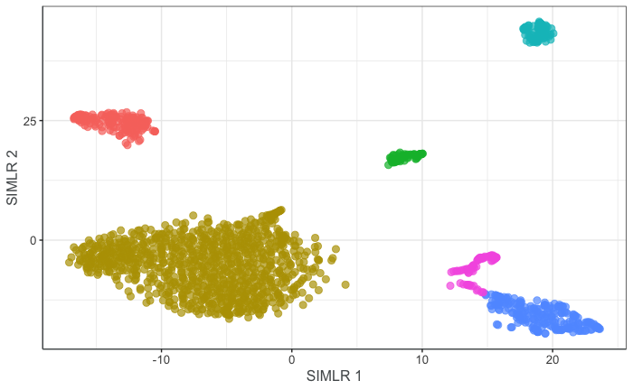

```r
# plot results
plot.DR(data.frame(retina_SIMLR$ydata), colorby = retina_SIMLR$y$cluster, name='SIMLR')
```

```r
write.csv(colon_SIMLR$F, file = 'Rmethods_out/colon_SIMLR_F.csv', row.names = F)
write.csv(colon_SIMLR$ydata, file = 'Rmethods_out/colon_SIMLR_ydata.csv', row.names = F)

write.csv(retina_SIMLR$F, file = 'Rmethods_out/retina_SIMLR_F.csv', row.names = F)
write.csv(retina_SIMLR$ydata, file = 'Rmethods_out/retina_SIMLR_ydata.csv', row.names = F)
```